# Python ka Chilla Witha Dr.Ammar

# Indexing and Data Structure

# - Indexing

*Make a string*

```python
a="Ladu Barfi"
a
```

```
'Ladu Barfi'
```

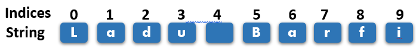

```python
a[0]
```

```
'L'
```

```python
a[6]
```

```
'a'
```

```python
a[9]
```

```
'i'
```

*Length of indces*

```python
len(a)
```

```
10
```

```python
a[9]
```

```
'i'
```

```python
a[0:3] #It mean 0 to 3
```

```
'Lad'
```

```python
a[0:4]
```

```
'Ladu'
```

*The lats index is exclusive means if we want to print ***"Ladu" *having 4 chracteres with indeces from* 0 to 3 *then we have to write in code* 0 to 4(0:4) *because the last index is not going to print.* *As we see above the output of* a[0:3]** is "Lad" not "Ladu".

### Negative Indexing

*Negative indexing start from the end of string as shown in the image below.*

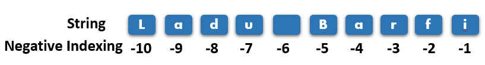

```python
a[-1]
```

```
'i'
```

```python
a[-7]
```

```
'u'
```

```python
a[-10]
```

```
'L'
```

*Now if we want to print Barfi by using negative indexing then we we'll do that as follow.*

```python
a[-6:-1] #last index is exlusive
```

```
' Barf'
```

```python
a[-5:10]
```

```
'Barfi'
```

## -String Methods

```python
food="biryani"
food
```

```
'biryani'
```

```python
food.capitalize()
```

```
'Biryani'
```

**Uppercase Letters**

```python
food.upper()
```

```
'BIRYANI'
```

**Lowercase Letters**

```python
food.lower()
```

```
'biryani'
```

**Replacement of Letters in a string**

```python
food.replace('b','Sh')
```

```
'Shiryani'
```

**Count a Spacific letter in a String**

```python
name="Muhammad Musharaf Ahsan"
name
```

```
'Muhammad Musharaf Ahsan'
```

```python
name.count("M")
```

```
2
```

**Finding an index number of sprific letter in a string**

```python
name.find("u")
```

```
1
```

```python
name.find("mm")
```

```
4
```

```python
name.find("m") #if there are more combinations of required alphabet then
               #it shows the index which come first in sequence
```

```
4
```

```python
name.find("Ahsan")
```

```
18
```

**How to Split a String**

```python
khana = "I love smosa pakora raita salad and qorma"
khana
```

```
'I love smosa pakora raita salad and qorma'
```

```python
khana.split(" ")                #Split string on the basis of space (" ").
```

```
['I', 'love', 'smosa', 'pakora', 'raita', 'salad', 'and', 'qorma']
```

```python
khana2="I love smosa, pakora, raita, salad and qorma"
khana2
```

```
'I love smosa, pakora, raita, salad and qorma'
```

```python
khana2.split(",")                #Split string on the basis of comma (",").
```

```
['I love smosa', ' pakora', ' raita', ' salad and qorma']
```

# - Basic Data Structure in Python

**1-Tuple**

**2-List**

**3-Dictionaries**

**4-Set**

## 1-Tuple

- Ordered colllection of Elements
- Enclosed in Parnthesis()
- Diffrent kind of elements can be stored
- Once elements are stored you can not change them(immutable)

```python
tup1=(90, "python", True, 3.5)
tup1
```

```
(90, 'python', True, 3.5)
```

```python
#Data type of a Typle
type(tup1)
```

```
tuple
```

### -Indexing in Tuple

```python
tup1[0]
```

```
90
```

```python
tup1[1]
```

```
'python'
```

```python
# We know that the last element is exclusive
tup1[0:3]
```

```
(90, 'python', True)
```

```python
#Length of a tuple or count total elements is a tuple
len(tup1)
```

```
4
```

```python
tup2=(4,"Ahsan", 9.4, False)
tup2
```

```
(4, 'Ahsan', 9.4, False)
```

```python
#Concatinate (to add two tuple or >2)
tup1+tup2
```

```
(90, 'python', True, 3.5, 4, 'Ahsan', 9.4, False)
```

```python
#Concatinate + repeat
tup1*2+tup2
```

```
(90, 'python', True, 3.5, 90, 'python', True, 3.5, 4, 'Ahsan', 9.4, False)
```

```python
tup3 =(32,42,44,67,78,88,90,10)
tup3
```

```
(32, 42, 44, 67, 78, 88, 90, 10)
```

```python
min(tup3)
```

```
10
```

```python
max(tup3)
```

```
90
```

```python
tup3*2 # with this method we can repeat the values of tuple not multiply like 2*2=4.
```

```
(32, 42, 44, 67, 78, 88, 90, 10, 32, 42, 44, 67, 78, 88, 90, 10)
```

## Other Functions Tuple

### 1- count

```python
tup3.count(44)
```

```
1
```

### 2- index

```python
tup3.index(78)
```

```
4
```

## 2-Lists

- Ordered collection of elements
- Enclosed in [ ] squar brackets
- Mutable (you can change the values)

```python
list1=[4, "Motu Patlu", 8.4, True]
list1
```

```
[4, 'Motu Patlu', 8.4, True]
```

```python
type(list1)
```

```
list
```

```python
len(list1)
```

```
4
```

```python
list1[3]
```

```
True
```

```python
list1*2
```

```
[4, 'Motu Patlu', 8.4, True, 4, 'Motu Patlu', 8.4, True]
```

```python
list2=[65, "I love Pakistan", "Musharaf Ahsan", 887, 9.5, False]
list2
```

```
[65, 'I love Pakistan', 'Musharaf Ahsan', 887, 9.5, False]
```

```python
list1+list2
```

```
[4,
 'Motu Patlu',
 8.4,
 True,
 65,
 'I love Pakistan',
 'Musharaf Ahsan',
 887,
 9.5,
 False]
```

## Other Functions of Lists

```python
list1
```

```
[4, 'Motu Patlu', 8.4, True]
```

### - Append()

*Used to insert or add new elements in the list.*

```python
list1.append("CUVAS")
list1
```

```
[4, 'Motu Patlu', 8.4, True, 'CUVAS']
```

### - Clear()

*This function delete every item from the list.*

```python
list1.clear()
list1
```

```
[]
```

```python
list1     # Here we saw that the list is empty.
```

```
[]
```

### - Copy()

```python
list1.copy() ##is ki samjh nhi ayeee
```

```
[]
```

### - Count()

*Python count() function is an inbuilt function of python which is used to count the number of occurrences of an item in an array/list and the occurrences of a character or substring in the string. Count function is case-sensitive it means that 'a' & 'A' are not treated as the same both are different.*

```python
list3=[1,0,0,"APE","CUVAS",2,2,0,1,"BWP"]
```

```python
list3
```

```
[1, 0, 0, 'APE', 'CUVAS', 2, 2, 0, 1, 'BWP']
```

```python
list3.count(0)
```

```
3
```

### - Extend()

```python
list3.extend("Ahsan")
list3
```

```
[1, 0, 0, 'APE', 'CUVAS', 2, 2, 0, 1, 'BWP', 'A', 'h', 's', 'a', 'n']
```

### - Indeex()

*index() is an inbuilt function in Python, which searches for a given element from the start of the list and returns the lowest index where the element appears.*

```python
list3.index('APE')
```

```
3
```

### - Insert()

*The Python List insert() method is an inbuilt function in Python that inserts a given element at a given index in a list.*

**Syntax:**

*list_name.insert(index, element)*

```python
list3.insert(2,"Ali") #Here we isert "Ali" at index 2.
list3
```

```
[1, 0, 'Ali', 0, 'APE', 'CUVAS', 2, 2, 0, 1, 'BWP', 'A', 'h', 's', 'a', 'n']
```

### - pop()

*Python list pop() is an inbuilt function in Python that removes and returns the last value from the List or the given index value.*

**Syntax:**

*list_name.pop(index)*

**Parameter:**

**index (optional) –** *The value at index is popped out and removed. If the index is not given, then the last element is popped out and removed.*

**Exception:** *When the index is out of range, it returns IndexError.*

```python
list3.pop(4)
list3
```

```
[1, 0, 'Ali', 0, 'CUVAS', 2, 2, 0, 1, 'BWP', 'A', 'h', 's', 'a', 'n']
```

```python
list3.pop()
```

```
'n'
```

```python
list3
```

```
[1, 0, 'Ali', 0, 'CUVAS', 2, 2, 0, 1, 'BWP', 'A', 'h', 's', 'a']
```

### - remove()

*remove() is an inbuilt function used to remove specific element rom the list.*

```python
list3.remove("CUVAS")
list3
```

```
[1, 0, 'Ali', 0, 2, 2, 0, 1, 'BWP', 'A', 'h', 's', 'a']
```

### - reverse()

*Used to reverse the list.*

```python
list3.reverse()
list3
```

```
['a', 's', 'h', 'A', 'BWP', 1, 0, 2, 2, 0, 'Ali', 0, 1]
```

### - Sort()

*Python list sort() function can be used to sort a List in ascending, descending, or user-defined order.*

```python
list4=[9,8,0,7,6,8,5,4,3,2,1,0]
list4
```

```
[9, 8, 0, 7, 6, 8, 5, 4, 3, 2, 1, 0]
```

**Ascending Order**

```python
list4.sort()
list4
```

```
[0, 0, 1, 2, 3, 4, 5, 6, 7, 8, 8, 9]
```

**Descending Order**

```python
list4.sort(reverse=True)
list4
```

```
[9, 8, 8, 7, 6, 5, 4, 3, 2, 1, 0, 0]
```

## 3-Dictionaries

- An unorddered collection of elements
- Contain two things Key an Value
- Enclosed in Curly Braces { }
- Mutable (you can change the values)

```python
# food and thier Prices
food1={"samosa":30, "Pakora":100, "raita":20, "salad":50, "chiken rolls":20}
food1
```

```
{'samosa': 30, 'Pakora': 100, 'raita': 20, 'salad': 50, 'chiken rolls': 20}
```

```python
type(food1)
```

```
dict
```

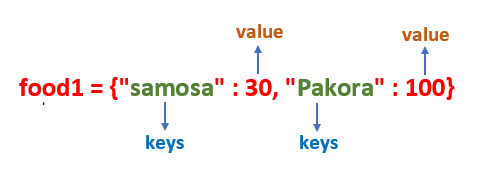

## Extract Data

### dict_keys

```python
keys=food1.keys() # also use as food1.keys
keys
```

```
dict_keys(['samosa', 'Pakora', 'raita', 'salad', 'chiken rolls'])
```

### dict_values

```python
food1.values()
```

```
dict_values([30, 100, 20, 50, 20])
```

### Adding New Elements

```python
food1["tikki"]=10
food1
```

```
{'samosa': 30,
 'Pakora': 100,
 'raita': 20,
 'salad': 50,
 'chiken rolls': 20,
 'tikki': 10}
```

### Update Values

```python
food1["tikki"]=15
food1
```

```
{'samosa': 30,
 'Pakora': 100,
 'raita': 20,
 'salad': 50,
 'chiken rolls': 20,
 'tikki': 15}
```

```python
food2={"Dates":50,"Choclate":200, "Sawayan":1000}
food2
```

```
{'Dates': 50, 'Choclate': 200, 'Sawayan': 1000}
```

### Concatinate

*The function ***(food1+food2)** does not work here.

```python
food1.update(food2)
food1
```

```
{'samosa': 30,
 'Pakora': 100,
 'raita': 20,
 'salad': 50,
 'chiken rolls': 20,
 'tikki': 15,
 'Dates': 50,
 'Choclate': 200,
 'Sawayan': 1000}
```

## Other Functions of Dictionaries

```python
clothes={"pant":1000, "shirt":500, "tie":200, "coat":2000}
clothes
```

```
{'pant': 1000, 'shirt': 500, 'tie': 200, 'coat': 2000}
```

### 1- clear()

*The clear() method removes all the elements from a dictionary*

```python
clothes.clear()
```

```python
clothes
```

```
{}
```

### 2- copy()

*The dict.copy() method returns a shallow copy of the dictionary.*

*The dictionary can also be copied using the = operator, which points to the same object as the original. So if any change is made in the copied dictionary will also reflect in the original dictionary.*

```python
clothes1={"pant":100, "shirt":200, "tie":100, "coat":5000}
clothes1
```

```
{'pant': 100, 'shirt': 200, 'tie': 100, 'coat': 5000}
```

```python
# By using copy() method..
clothes2=clothes1.copy()
clothes2
```

```
{'pant': 100, 'shirt': 200, 'tie': 100, 'coat': 5000}
```

```python
# By using assignment "=" operator..
clothes3=clothes1
clothes3
```

```
{'pant': 100, 'shirt': 200, 'tie': 100, 'coat': 5000}
```

### 3- fromkeys()

*The fromkeys() method returns a dictionary with the specified keys and the specified value.*

### Syntax

*dict.fromkeys(keys, value)*

### Parameter Values

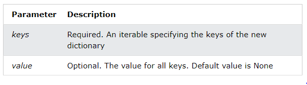

```python
# 1st Method
clothes1.fromkeys(clothes1,90)
```

```
{'pant': 90, 'shirt': 90, 'tie': 90, 'coat': 90}
```

```python
# 2nd Method
key =("oppo","samsung","iphone","vivo")
value =(100000)
cell_price = dict.fromkeys(key,value)
cell_price
```

```
{'oppo': 100000, 'samsung': 100000, 'iphone': 100000, 'vivo': 100000}
```

### 4- get()

*The get() method returns the value of the item with the specified key.*

### Syntax

*dictionary.get(keyname, value)*

### Parameter Values

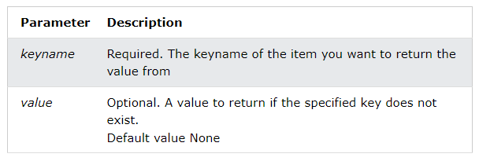

```python
clothes1.get("pant")
```

```
100
```

```python
food1.get("samosa")
```

```
30
```

### 5- items()

*A items() method is used with a dictionary to get the list with all dictionary keys with values.*

### Syntax

*dictionary.items()*

```python
food1.items()
```

```
dict_items([('samosa', 30), ('Pakora', 100), ('raita', 20), ('salad', 50), ('chiken rolls', 20), ('tikki', 15), ('Dates', 50), ('Choclate', 200), ('Sawayan', 1000)])
```

### 6- keys()

```python
food1.keys()
```

```
dict_keys(['samosa', 'Pakora', 'raita', 'salad', 'chiken rolls', 'tikki', 'Dates', 'Choclate', 'Sawayan'])
```

### 7- pop()

*The pop() method removes the specified item from the dictionary.*

### Syntax

*dictionary.pop(keyname, defaultvalue)*

### Parameter Values

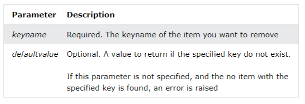

```python
food1.pop("samosa")
```

```
30
```

```python
food1      # samosa from the dictionary is removed
```

```
{'Pakora': 100,
 'raita': 20,
 'salad': 50,
 'chiken rolls': 20,
 'tikki': 15,
 'Dates': 50,
 'Choclate': 200,
 'Sawayan': 1000}
```

### 8- popitem()

*The popitem() method removes the item that was last inserted into the dictionary. In versions before 3.7, the popitem() method removes a random item.*

### Syntax

*dictionary.popitem()*

```python
food1.popitem()
```

```
('Sawayan', 1000)
```

### 9-setdefault()

*The setdefault() method returns the value of the item with the specified key.*

### Syntax

*dictionary.setdefault(keyname, value)*

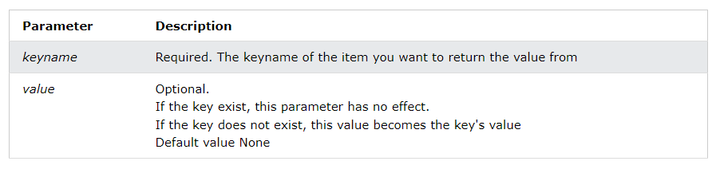

```python
food1.setdefault("raita")
```

```
20
```

```python
food1.setdefault("Dates",50)
```

```
50
```

### 10- update()

*The update() method inserts the specified items to the dictionary.*

*The specified items can be a dictionary, or an iterable object with key value pairs.*

### Syntax

*dictionary.update(iterable)*

### Parameter Values

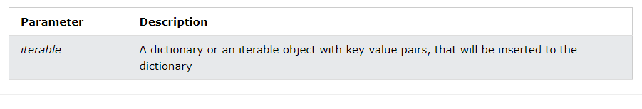

```python
food1.update({"burger":150})
```

```python
food1
```

```
{'Pakora': 100,
 'raita': 20,
 'salad': 50,
 'chiken rolls': 20,
 'tikki': 15,
 'Dates': 50,
 'Choclate': 200,
 'burger': 150}
```

## 4-Set

- Unordered and unindexed
- Curly braces are used { }
- No duplicates are allowed

```python
s1={1, 2.5, 5.6, "Musharaf", "CUVAS", True} # bolian operator add nhi kr sakte wo print nhi ho ga
s1
```

```
{1, 2.5, 5.6, 'CUVAS', 'Musharaf'}
```

### 1- add()

*The add() method adds an element to the set.*

*If the element already exists, the add() method does not add the element.*

### Syntax

*set.add(elmnt)*

```python
s1.add("Musharaf") # Duplicate items add nhi ho gy.
s1
```

```
{1, 2.5, 5.6, 'CUVAS', 'Musharaf'}
```

### 2- clear()

*The clear() method removes all elements in a set.*

### Syntax

*set.clear()*

```python
s1.clear()
```

```python
s1
```

```
set()
```

```python
s={88, 8.9, 0.45, "Akif", "boss"}
```

### 3- copy()

*The copy() method copies the set.*

### Syntax

*set.copy()*

```python
copy_set=s.copy()
```

```python
copy_set
```

```
{0.45, 8.9, 88, 'Akif', 'boss'}
```

```python
s2={0.45, 8.9, "Ahsan", "boss", "asfand"}
```

### 4- difference()

*The difference() method returns a set that contains the difference between two sets.*

*Meaning: The returned set contains items that exist only in the first set, and not in both sets.*

### Syntax

*set.difference(set)*

```python
x=s.difference(s2)
```

```python
x
```

```
{88, 'Akif'}
```

```python
y=s2.difference(s)
y
```

```
{'Ahsan', 'asfand'}
```

### 5- difference_update()

*The difference_update() method removes the items that exist in both sets.*

*The difference_update() method is different from the difference() method, because the difference() method returns a new set, without the unwanted items, and the difference_update() method removes the unwanted items from the original set.*

### Syntax

*set.difference_update(set)*

```python
a=s.difference_update(s2)
```

```python
s
```

```
{88, 'Akif'}
```

```python
b=s2.difference_update(s) #from s={88, "Akif"} & s2={0.45, 8.9, 'Ahsan', 'asfand', 'boss'} common is nothing
```

```python
s2
```

```
{0.45, 8.9, 'Ahsan', 'asfand', 'boss'}
```

### 6- discard()

*The discard() method removes the specified item from the set.*

*This method is different from the remove() method, because the remove() method will raise an error if the specified item does not exist, and the discard() method will not.*

### Syntax

*set.discard(value)*

```python
s3={"python", "c++", "c", 99, 99.09}
```

```python
s3
```

```
{99, 99.09, 'c', 'c++', 'python'}
```

```python
s3.discard("c++")
```

```python
s3
```

```
{99, 99.09, 'c', 'python'}
```

### 7- intersection()

*The intersection() method returns a set that contains the similarity between two or more sets.*

*Meaning: The returned set contains only items that exist in both sets, or in all sets if the comparison is done with more than two sets.*

### Syntax

*set.intersection(set1, set2 ... etc)*

```python
s4={99.09, 99, "dell", "hp", "Apple", "python"}
```

```python
s5={"dell", "python", 99 }
```

```python
s3.intersection(s4,s5)
```

```
{99, 'python'}
```

### 8- intersection_update()

*The intersection_update() method removes the items that is not present in both sets (or in all sets if the comparison is done between more than two sets).*

*The intersection_update() method is different from the intersection() method, because the intersection() method returns a new set, without the unwanted items, and the intersection_update() method removes the unwanted items from the original set.*

### Syntax

*set.intersection_update(set1, set2 ... etc)*

```python
s4.intersection_update(s5)
```

```python
s4
```

```
{99, 'dell', 'python'}
```

### 9- isdisjoint()

*The isdisjoint() method returns True if none of the items are present in both sets, otherwise it returns False.*

### Syntax

*set.isdisjoint(set)*

```python
s4.isdisjoint(s5)
```

```
False
```

### 10- issubset()

*The issubset() method returns True if all items in the set exists in the specified set, otherwise it retuns False.*

### Syntax

*set.issubset(set)*

```python
s6={"a","b","d",9,8,7,6,3}
```

```python
s7={"a","b","c","d","e","f","g",1,2,3,4,5,6,7,8,9,10,11,12}
```

```python
s6.issubset(s7)
```

```
True
```

```python
s4.issubset(s6)
```

```
False
```

### 11- issuperset()

*The issuperset() method returns True if all items in the specified set exists in the original set, otherwise it retuns False.*

### Syntax

*set.issuperset(set)*

```python
s6.issuperset(s7)
```

```
False
```

```python
s7.issuperset(s6)
```

```
True
```

### 12- pop()

*The pop() method removes a random item from the set.*

*This method returns the removed item.*

### Syntax

*set.pop()*

```python
s6.pop()
```

```
3
```

### 13- remove()

*The remove() method removes the specified element from the set.*

*This method is different from the discard() method, because the remove() method will raise an error if the specified item does not exist, and the discard() method will not.*

### Syntax

*set.remove(item)*

```python
s6.remove(9)
```

```python
s6
```

```
{6, 7, 8, 'a', 'b', 'd'}
```

### 14- symmetric_difference()

*The symmetric_difference() method returns a set that contains all items from both set, but not the items that are present in both sets.*

*Meaning: The returned set contains a mix of items that are not present in both sets.*

### Syntax

*set.symmetric_difference(set)*

```python
s6.symmetric_difference(s7)
```

```
{1, 10, 11, 12, 2, 3, 4, 5, 9, 'c', 'e', 'f', 'g'}
```

### 15- symmetric_difference_update()

*The symmetric_difference_update() method updates the original set by removing items that are present in both sets, and inserting the other items.*

### Syntax

*set.symmetric_difference_update(set)*

```python
s8=s6.symmetric_difference_update(s7)
```

```python
s6
```

[output not shown]

### 16- union()

*The union() method returns a set that contains all items from the original set, and all items from the specified set(s).*

*You can specify as many sets you want, separated by commas.*

*It does not have to be a set, it can be any iterable object.*

*If an item is present in more than one set, the result will contain only one appearance of this item.*

### Syntax

*set.union(set1, set2...)*

```python
s8={1,2,3,4,5,6,7,7,8,9,10}
```

```python
s9={"a","b","c","d",1,2,4,4,5}
```

```python
s8.union(s9)
```

```
{1, 10, 2, 3, 4, 5, 6, 7, 8, 9, 'a', 'b', 'c', 'd'}
```

### 17- update()

*The update() method updates the current set, by adding items from another set (or any other iterable).*

*If an item is present in both sets, only one appearance of this item will be present in the updated set.*

### Syntax

*set.update(set)*

```python
s8.update(s9)
```

[output not shown]